# Animals Vax Atlas

[figure not shown]

> **Associated manuscript:**  
> *From Mice to Humans: Functional Modules Improve the Translatability of Transcriptomic Responses*  
> Wasim Aluísio Prates-Syed, Aline A. Lira, Nelson Cortes, Jaqueline D.Q. Silva, Bárbara Hamaguchi, Evelyn Carvalho, Adriana Castillo-Chávez, Ricardo Durães-Carvalho, Otavio Cabral-Marques, Ester Cerdeira Sabino, José Eduardo Krieger, Thomas Hagan, Gustavo Cabral-Miranda.  
> *Submitted to Genes and Immunity — currently under review.*

## Overview

Mice are the dominant preclinical model in vaccine research, yet their translational value for human immune responses remains contested. This project systematically evaluates murine translatability across vaccination (Influenza, Hepatitis B), acute bacterial infection (*S. aureus*, *E. coli*), and sterile injury (burns and trauma) using publicly available blood transcriptome data from GEO/BioProject.

A key finding is that while individual orthologous gene correlations are often low, **higher-order pathway and module responses are highly conserved** between species. By shifting from a gene-level to a pathway-level analytical framework — using Blood Transcription Modules (BTMs) and rank-based statistics — murine models accurately predict human immune dynamics. Translational accuracy scales with stimulus intensity: acute infections and systemic injuries show the highest conservation, while milder vaccination stimuli reveal greater species-specific divergence. Divergent gene expression is linked to differences in *cis*-regulatory architecture, not protein sequence identity.

## Conditions Covered

| Challenge | Vaccine / Agent | Organisms |
| --- | --- | --- |
| Influenza | Fluad (TIV + MF59) | Human, Mouse |
| Hepatitis B | Engerix B | Human, Mouse |
| *Staphylococcus aureus* infection | — | Human, Mouse |
| *Escherichia coli* infection | — | Human, Mouse |
| Burn / Trauma | — | Human, Mouse |

## Analysis Workflow

```
flowchart TD
    A[("🔍 BioProject / GEO\nSearch & Curation\n0_Data_Curation.Rmd")]
    B["🧪 Quality Control\nArray quality metrics,\noutlier detection\n1_QualityControl.Rmd"]
    C["⚙️ Preprocessing\nGEO download, normalization,\nprobe mapping, log2FC\n2_Preprocessing.Rmd"]
    D["📊 Cross-Species Comparison\nlimma DGE · GSEA/ssGSEA\nBTMs · Hallmarks · RRHO2\n3_Comparing_Human_Mouse.Rmd"]
    E["📈 Performance Evaluation\nROC curves · FIT predictor\nAll genes vs. immune genes\n4_Performance.Rmd"]
    F["🤖 Machine Learning\nCross-species classifiers\n5_MachineLearning.Rmd"]
    G[("🧬 Genomic / cis-Regulatory\nPromoter sequences · TF analysis")]

    A --> B --> C --> D --> E --> F
    C --> G
    G --> D
```

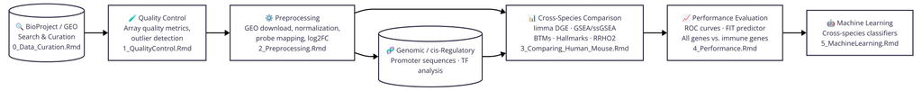

The notebooks are designed to be run in order:

1. **`0_Data_Curation.Rmd`** — Searches BioProject for vaccination/immunization studies, filters by organism and design criteria, and produces a curated dataset list.
2. **`1_QualityControl.Rmd`** — Runs array quality metrics (AQM) to flag low-quality samples and outliers before integration.
3. **`2_Preprocessing.Rmd`** — Downloads ExpressionSets from GEO via `GEOquery`, applies quantile normalization, maps probes to gene symbols via `biomaRt`, and computes sample-level log2 fold-changes vs. Day 0 baseline.
4. **`3_Comparing_Human_Mouse.Rmd`** — Core analysis:
   - Differential expression with `limma`
   - GSEA and ssGSEA using BTMs and MSigDB Hallmarks
   - Cross-species correlation of module NES scores and mean log2FCs
   - RRHO2 rank-rank hypergeometric overlap
   - Shared/unique DEG analysis (Fisher/Jaccard statistics)
5. **`4_Performance.Rmd`** — Evaluates mouse-to-human predictive performance via ROC curves across all conditions, stratified by all genes vs. immune gene subsets.
6. **`5_MachineLearning.Rmd`** — Builds machine learning classifiers for cross-species response prediction.

## Repository Structure

```
animals_vax_atlas/
├── scripts_notebooks/
│   ├── required.R                   # Packages, theme, utility functions, palettes
│   ├── 0_Data_Curation.Rmd
│   ├── 1_QualityControl.Rmd
│   ├── 2_Preprocessing.Rmd
│   ├── 3_Comparing_Human_Mouse.Rmd
│   ├── 4_Performance.Rmd
│   ├── 5_MachineLearning.Rmd
│   └── FIT_training_datasets.Rmd
├── DataCuration/                    # Raw BioProject exports and manual annotation files
├── tables/                          # Processed data (RDS, CSV) — main data store
├── VaxGO/                           # Gene set files (BTMs, ImmuneGO, VaxSigDB, Hallmarks)
├── Genomic/                         # Promoter sequences (FASTA)
├── Figures/                         # Generated plots
├── Figures_Article/                 # Publication-ready figures
├── ArrayQM/                         # AQM HTML reports
├── Codebook_MouseToHuman.xlsx       # Cross-species gene mapping codebook
└── renv.lock                        # Package snapshot
```

## Gene Sets Used

| Gene Set | Description |
| --- | --- |
| **BTMs** | Blood Transcription Modules (Li et al.) — immune cell-type and process modules |
| **MSigDB Hallmarks** | Broad hallmark gene sets from MSigDB |
| **ImmuneGO** | Custom mouse-adapted immune Gene Ontology annotations |
| **VaxSigDB** | Vaccination signature gene sets |

## Reproducing the Analysis

All packages are managed with [`renv`](https://rstudio.github.io/renv/). To restore the environment:

```r
renv::restore()
```

Each notebook sources `scripts_notebooks/required.R`, which loads all packages and defines the shared `theme_vaxgo` ggplot2 theme, color palettes, and utility functions (GSEA wrappers, ORA helpers, safe correlation, etc.).

**CRAN** (selected): `tidyverse`, `patchwork`, `tidymodels`, `ggrepel`, `corrr`, `GGally`, `rstatix`, `FactoMineR`, `ComplexHeatmap`

**Bioconductor** (selected): `GEOquery`, `biomaRt`, `limma`, `edgeR`, `DESeq2`, `GSVA`, `clusterProfiler`, `fgsea`, `msigdbr`, `org.Hs.eg.db`, `sva`

**GitHub**: [`RRHO2`](https://github.com/RRHO2/RRHO2)

## Key Data Files

Raw and intermediate data live in `tables/`. Key files:

| File | Description |
| --- | --- |
| `all_human_mouse_metadata.rds` | Combined sample metadata across all conditions |
| `all_degs_human_mouse.rds` | Pooled differential expression results |
| `btm_annotation_genes.csv` | BTM gene set annotations |
| `msigdb_hallmarks_grouped_genes.csv` | Hallmark gene set annotations |
| `influenza_fluad_human_mouse_eset.rds` | Example integrated ExpressionSet (Fluad) |

Processed files follow the naming convention:  
`{pathogen}_{condition}_{organism}_{datatype}.rds`

## Citation

If you use this code or data, please cite:

> Prates-Syed WA, Lira AA, Cortes N, Silva JDQ, Hamaguchi B, Carvalho E, Castillo-Chávez A, Durães-Carvalho R, Cabral-Marques O, Sabino EC, Krieger JE, Hagan T, Cabral-Miranda G. *From Mice to Humans: Functional Modules Improve the Translatability of Transcriptomic Responses.* Genes and Immunity (under review).

## License

See LICENSE.